# PCA, Ca & MCA

Ming Li

Monday, August 11, 2014

**Content list**

- Principal components analysis (PCA)
- Correspondence analysis (CA)
- Multiple correspondence analysis (MCA)

### 1. Principal components analysis

ref: http://factominer.free.fr/classical-methods/principal-components-analysis.html

#### data

```r
data(decathlon)
summary(decathlon)
```

```
##       100m        Long.jump       Shot.put      High.jump
##  Min.   :10.4   Min.   :6.61   Min.   :12.7   Min.   :1.85
##  1st Qu.:10.8   1st Qu.:7.03   1st Qu.:13.9   1st Qu.:1.92
##  Median :11.0   Median :7.30   Median :14.6   Median :1.95
##  Mean   :11.0   Mean   :7.26   Mean   :14.5   Mean   :1.98
##  3rd Qu.:11.1   3rd Qu.:7.48   3rd Qu.:15.0   3rd Qu.:2.04
##  Max.   :11.6   Max.   :7.96   Max.   :16.4   Max.   :2.15
##       400m       110m.hurdle       Discus       Pole.vault
##  Min.   :46.8   Min.   :14.0   Min.   :37.9   Min.   :4.20
##  1st Qu.:48.9   1st Qu.:14.2   1st Qu.:41.9   1st Qu.:4.50
##  Median :49.4   Median :14.5   Median :44.4   Median :4.80
##  Mean   :49.6   Mean   :14.6   Mean   :44.3   Mean   :4.76
##  3rd Qu.:50.3   3rd Qu.:15.0   3rd Qu.:46.1   3rd Qu.:4.92
##  Max.   :53.2   Max.   :15.7   Max.   :51.6   Max.   :5.40
##     Javeline        1500m          Rank          Points       Competition
##  Min.   :50.3   Min.   :262   Min.   : 1.0   Min.   :7313   Decastar:13
##  1st Qu.:55.3   1st Qu.:271   1st Qu.: 6.0   1st Qu.:7802   OlympicG:28
##  Median :58.4   Median :278   Median :11.0   Median :8021
##  Mean   :58.3   Mean   :279   Mean   :12.1   Mean   :8005
##  3rd Qu.:60.9   3rd Qu.:285   3rd Qu.:18.0   3rd Qu.:8122
##  Max.   :70.5   Max.   :317   Max.   :28.0   Max.   :8893
```

#### objectives

- PCA 可以描述、总结一个数据集，对数据集降维
- 从行的角度：将每一行看成一个individual；通过观察individuals在各个variable上的得分是否接近来判断两个individual是否类似，进而可以对individuals进行分组；
- 从列的角度：每一列都是一个viariable，要回答的问题是变量之间是否存在线性关系，进而能将变量合成为几个有限的变量？
- 综合考虑：原本的相关矩阵是非常大的，要回答的问题是：能否找到几个合成变量(synthetic variables),可以让我们通过有限的几个维度来描述individuals，进而对individuals进行分组？

##### a) active individuals and active variables

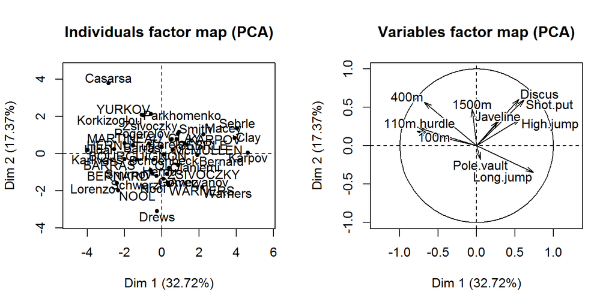

```r
par(mfrow=c(1,2))
res.pca = PCA(decathlon[,1:10], scale.unit=TRUE, ncp=5, graph=T)
```

- 基于active variables进行的分析
- 得到的前两个维度占据了50%的total inertia (即数据集的总方差，亦即相关矩阵的秩)
  - 坐标轴的解释：可以将第一个轴看作是速度相关，第二个轴看作是力量相关；
  - 坐标轴对应到variables factor可以看到100m和速度相关，而掷铁饼(discus)等等和力量相关；
  - 坐标轴对应到individual factor可以大致将运动员分为四组。

##### b) supplementary variables

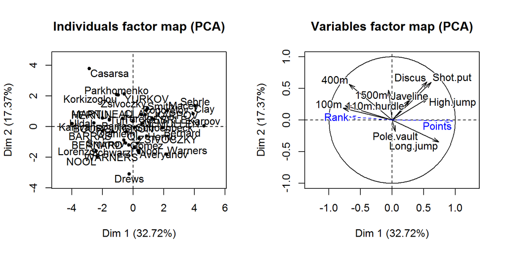

```r
par(mfrow=c(1,2))
res.pca = PCA(decathlon[,1:12], scale.unit=TRUE, ncp=5, quanti.sup=c(11: 12), graph=T)
```

* 这种变量对主成分分析没有影响，他们是为了帮助解释dimensions of variability. * 解释：得分/名词速度相关的影响更大(受百米影响很大，几乎不受1500m的影响)

##### c) supplementary individuals

如果不希望某些individual参与分析，就将该记录列为supplementary individual。那么这个individual将不会参与分析，但会提供额外的信息。方法是：

```
ind.sup
```

supplementary variables也可以是分类变量。

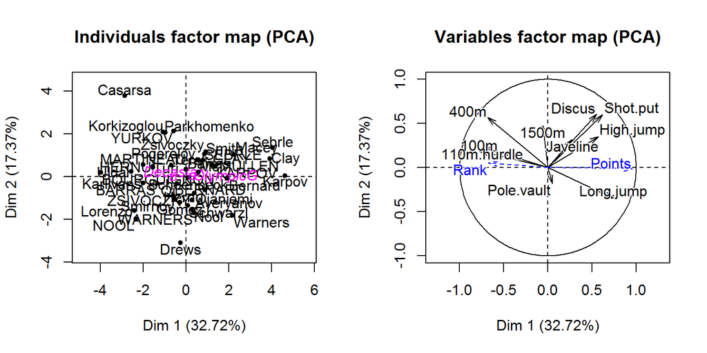

```r
par(mfrow=c(1,2))
res.pca = PCA(decathlon, scale.unit=TRUE, ncp=5, quanti.sup=c(11: 12), quali.sup=13, graph=T)
```

分类补充变量是画在individual的图上的，位置分别是它们各自的质心。也可以用颜色标注出来：

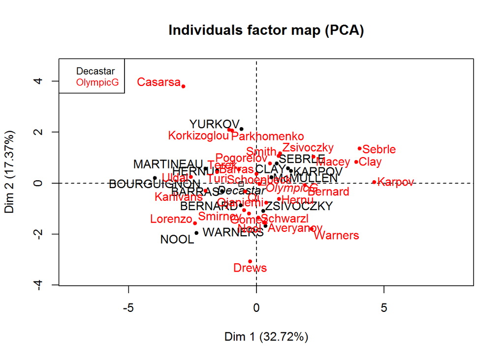

```r
plot.PCA(res.pca, axes=c(1, 2), choix="ind", habillage=13)
```

* olympics比Decastar在第一个轴上的位置更高，说明运动员在olympics上的成绩更好。

对维度的描述：dimdesc函数计算某variable和轴之间的相关系数，并进行显著性检验。

```r
dimdesc(res.pca, axes=c(1,2))
```

```
## $Dim.1
## $Dim.1$quanti
##             correlation   p.value
## Points           0.9562 0.000e+00
## Long.jump        0.7419 2.850e-08
## Shot.put         0.6225 1.388e-05
## High.jump        0.5719 9.362e-05
## Discus           0.5525 1.802e-04
## Rank            -0.6705 1.616e-06
## 400m            -0.6796 1.028e-06
## 110m.hurdle     -0.7462 2.137e-08
## 100m            -0.7747 2.778e-09
##
##
## $Dim.2
## $Dim.2$quanti
##           correlation   p.value
## Discus         0.6063 2.651e-05
## Shot.put       0.5983 3.604e-05
## 400m           0.5694 1.021e-04
## 1500m          0.4742 1.734e-03
## High.jump      0.3503 2.475e-02
## Javeline       0.3170 4.345e-02
## Long.jump     -0.3454 2.697e-02
```

### 3. Multiple correspondence analysis

ref: http://factominer.free.fr/classical-methods/multiple-correspondence-analysis.html

#### data

```r
data(tea)
summary(tea)
```

```
##          breakfast           tea.time          evening          lunch
##  breakfast    :144   Not.tea time:131   evening    :103   lunch    : 44
##  Not.breakfast:156   tea time    :169   Not.evening:197   Not.lunch:256
##
##
##
##
##
##         dinner           always          home           work
##  dinner    : 21   always    :103   home    :291   Not.work:213
##  Not.dinner:279   Not.always:197   Not.home:  9   work    : 87
##
##
##
##
##
##         tearoom           friends          resto          pub
##  Not.tearoom:242   friends    :196   Not.resto:221   Not.pub:237
##  tearoom    : 58   Not.friends:104   resto    : 79   pub    : 63
##
##
##
##
##
##         Tea         How           sugar                     how
##  black    : 74   alone:195   No.sugar:155   tea bag           :170
##  Earl Grey:193   lemon: 33   sugar   :145   tea bag+unpackaged: 94
##  green    : 33   milk : 63                  unpackaged        : 36
##                  other:  9
##
##
##
##                   where                 price          age     sex
##  chain store         :192   p_branded      : 95   Min.   :15   F:178
##  chain store+tea shop: 78   p_cheap        :  7   1st Qu.:23   M:122
##  tea shop            : 30   p_private label: 21   Median :32
##                             p_unknown      : 12   Mean   :37
##                             p_upscale      : 53   3rd Qu.:48
##                             p_variable     :112   Max.   :90
##
```

[output cut: 25 more lines]

```
##  feminine    :129   Not.sophisticated: 85   No.slimming:255
##  Not.feminine:171   sophisticated    :215   slimming   : 45
##
##
##
##
##
##         exciting          relaxing              effect.on.health
##  exciting   :116   No.relaxing:113   effect on health   : 66
##  No.exciting:184   relaxing   :187   No.effect on health:234
##
##
##
##
##
```

#### objectives

- individuals: two individuals are close to each other if they answered the questions the same way;=> are there groups of individuals?
- categories: tow categories are close to each other if they are often taken together;
- variables: looking for one or several continuous synthetical variables to summarize categorical ones

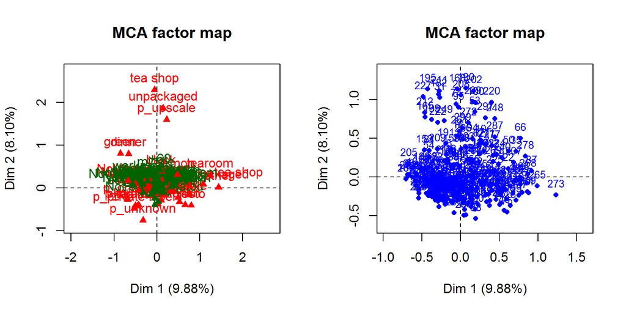

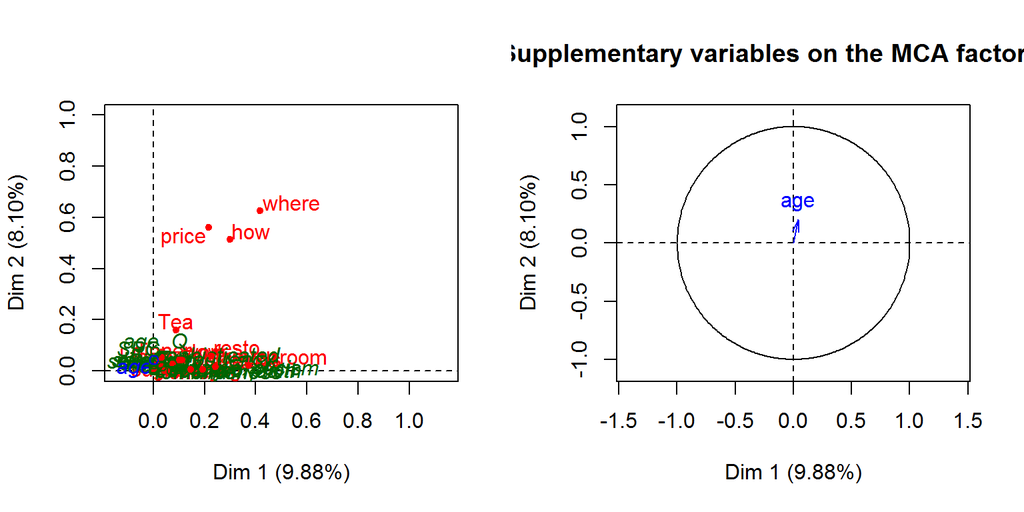

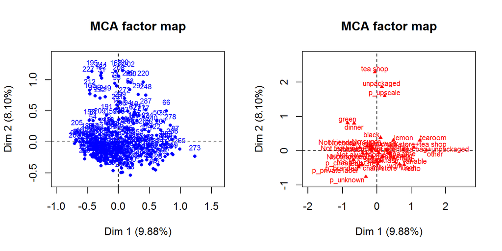

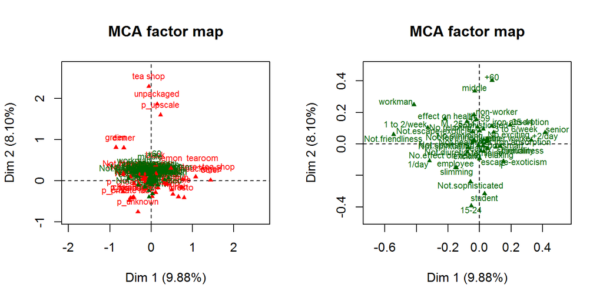